# HW#2e9-main

## Joint Spatial Analysis & Field Forecasting using CCA

### (i) Take the leading ~ 5 PCs of the winter SSTs and perform CCA with the leading ~ 5 PCs of winter precipitation.

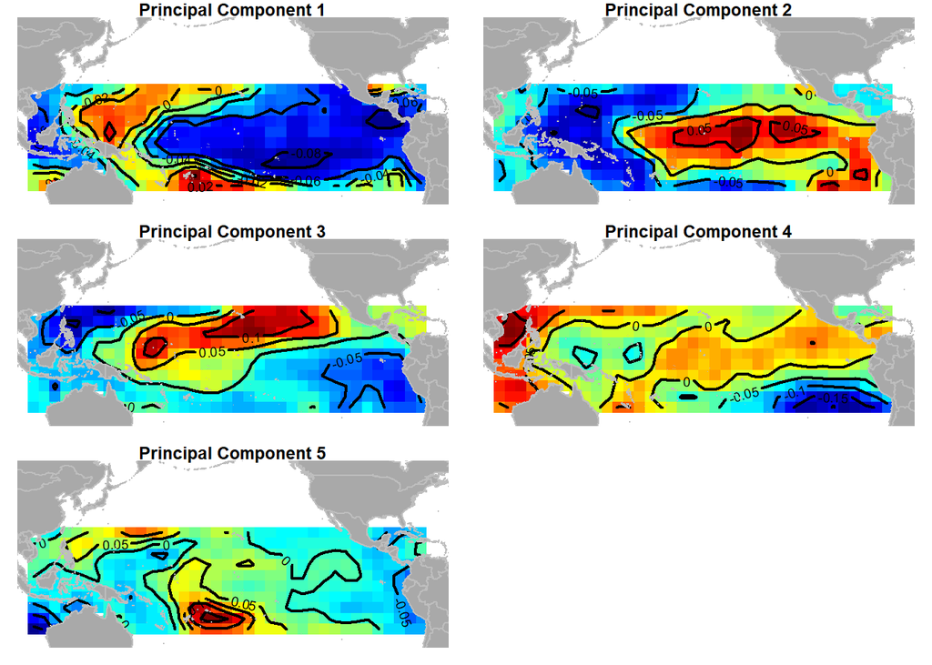

```r
## PCA on Western US precip anomalies
p.svd = wintanom %>% scale(.) %>% var(.) %>% svd(.) # Eigen decomposition
p.pcs= t(t(p.svd$u) %*% t(scale(wintanom))) %>% scale(.) # Principal Components
p.lambdas=(p.svd$d/sum(p.svd$d)) # Eigenvalues

## PCA on Pacific SST anomalies
t.svd = sstannavg %>% scale(.) %>% var(.) %>% svd(.) # Eigen decomposition
t.pcs=t(t(t.svd$u) %*% t(scale(sstannavg))) %>% scale(.) # Principal Components
t.lambdas=(t.svd$d/sum(t.svd$d)) # Eigenvalues

# Plot the PCs

par(mfrow=c(3,2))
par(mar=c(1,1,1,1))

for(i in 1:5){
  zfull = rep(NA,length(xygrid[,1]))
  zfull[indexpac]=t.svd$u[,i]
  zmat = matrix(zfull,nrow=72,ncol=36)

  image(xgrid,ygrid,zmat,ylim=range(-25,50),
             xlim=range(100,300),asp = 1,col=tim.colors(n = 64, alpha=1.0),
             main=paste("Principal Component",i),axes=FALSE,
             xlab="", ylab="" )
  contour(xgrid,ygrid,zmat,ylim=range(-25,50),xlim=range(100,300),
          add=TRUE,nlev=6,lwd=2)
  map("world2",fill = TRUE,col="darkgray",border="gray",add=TRUE)
}
par(mfrow=c(1,1))
```

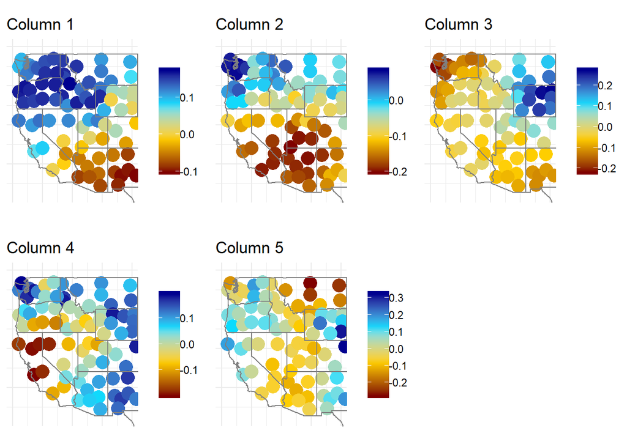

```r
par(mar=c(5.1, 4.1, 4.1, 2.1))

# Plot the PCs
comp = cbind(xlongs,xlats,p.svd$u)
comp = as.data.frame(comp) # data frame
colnames(comp) = c("xlongs","xlats","PC1","PC2","PC3","PC4","PC5")

p_map = function(comp,i){ # plots a ggplot given the column "i" of comp
  ggplot(comp,aes(x = xlongs,y = xlats)) +
  geom_point(aes_string(colour=colnames(comp)[i+2]),size = 5) +
  scale_colour_gradientn(colours = rev(tim.colors(n=4))) +
      theme_minimal() +
  ggtitle(paste("Column",i))+
  borders('state') +
  coord_quickmap(xlim=c(-125,-105),ylim=c(31,50)) +
  theme(legend.position = "right",axis.title.x=element_blank(),
         axis.title.y=element_blank(),legend.title=element_blank(),
        axis.text.x=element_blank(),axis.text.y=element_blank(),
        plot.margin = margin(0.1, 0.1, 0.1, 0.1, "cm"))}

grid.arrange(p_map(comp,1),p_map(comp,2),p_map(comp,3),p_map(comp,4),
             p_map(comp,5),nrow = 2, ncol = 3)
```

```r
#   breaks = c(0,0.25,0.5,0.75,1)
#   breaks = quantile(as.matrix(comp[,-c(1,2)]))
#   scale_colour_gradientn(colours = rev(tim.colors(n=4)), breaks = breaks) +
```

The Canonical Correlation Analysis is carried out using the first 5 PCs of SST, precip. The resulsts are checked against the built-in function *stats::cancor*.

```r
npc= 5 # N. of PCA to do CCA
p.pc=p.pcs[,1:npc] # select first 5
t.pc=t.pcs[1:113,1:npc] # select first 5

N = min(dim(p.pc)[1],dim(t.pc)[1]) # Time series

Qx1 = qr.Q(qr(t.pc))
Qy1 = qr.Q(qr(p.pc))
T11 = qr.R(qr(t.pc))
T22 = qr.R(qr(p.pc))
VV=t(Qx1) %*% Qy1
BB = svd(VV)$v
AA = svd(VV)$u
BB = solve(T22) %*% svd(VV)$v * sqrt(N-1)
wm1 = p.pc %*% BB
AA = solve(T11) %*% svd(VV)$u * sqrt(N-1)
vm1 = t.pc %*% AA
cancorln = svd(VV)$d[1:npc] #canonical correlation
Fyy = var(p.pc) %*% BB

cca=cancor(t.pc,p.pc) # Check results with built-in function
print(cancorln)
```

```
## [1] 0.69941728 0.40952483 0.29513692 0.27522682 0.02010316
```

```r
print(cca$cor)
```

```
## [1] 0.69974432 0.41044352 0.29558939 0.27557670 0.02011137
```

The results obtained from the principles approach are equivalent to the ones using the built-in *cancor* function

### (ii) Fit a regression for each canonical variate of precipitation related to canonical variate of SSTs.

The linear parameters obtained from the CCA are used to predict the PC of precipitation.

```r
betahat = solve(t(AA) %*% t(t.pc)%*% t.pc %*% AA) %*% t(AA) %*% t(t.pc) %*% p.pc

ypred=t.pc %*% AA %*% betahat # linear prediction of precip PC. using SST PC
```

#### Use these regressions to predict the flow variates and back transform them to the original space – i.e., the precipitation space.

Two alternatives are used, having high correlation (positive or negative)

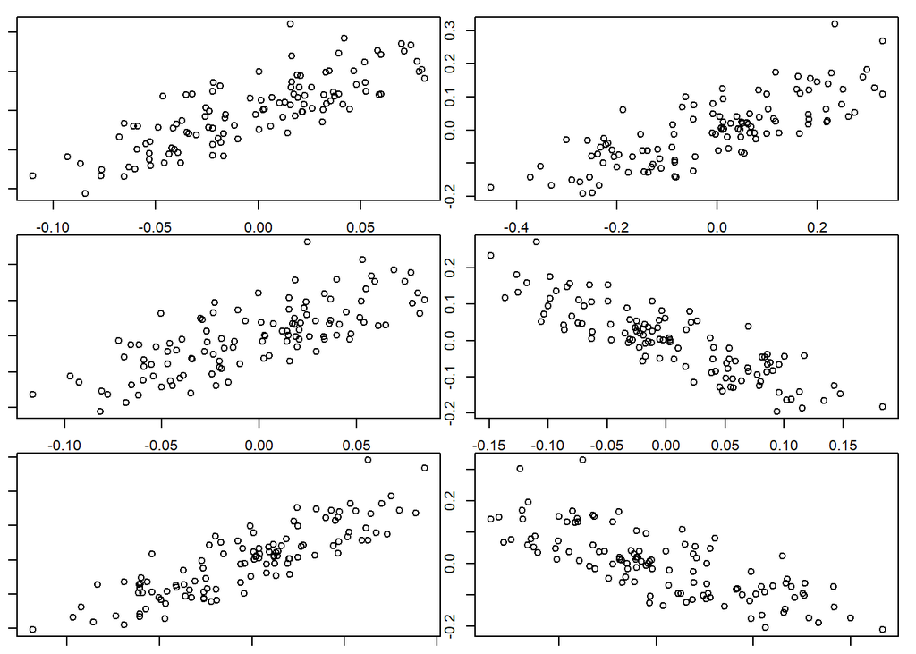

```r
p.pred.pc=matrix(0,nrow = dim(p.pcs)[1],ncol = dim(p.pcs)[2])
p.pred.pc[,1:npc] = ypred # linear prediction of precip PC. using SST PC (whole space)

wintanom.pred = p.pred.pc %*% p.svd$u # scaled precip. prediction. Full eof

E = p.svd$u
E[,(npc+1):81]=0

wintanom.pred2= p.pred.pc %*% t(E) # scaled precip. prediction. Partial eof

par(mfrow=c(3,2))
par(mar=c(1,1,1,1))

for(i in 1:6){
  plot(wintanom.pred[,i],wintanom.pred2[,i],xlab = "",ylab="")
}
```

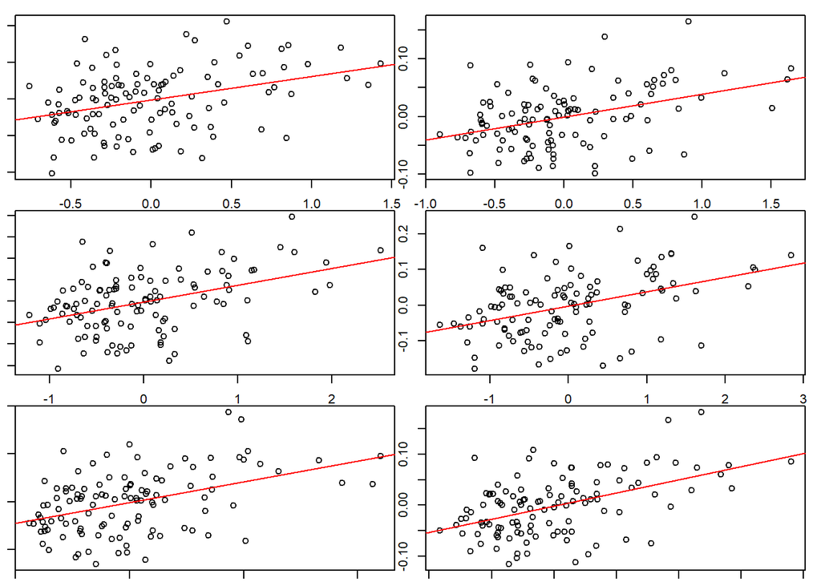

```r
par(mfrow=c(1,1))
par(mar=c(5.1, 4.1, 4.1, 2.1))

p.mean = apply(wintanom, 2, mean)
p.sd = apply(wintanom, 2, sd)

wintanom.pred=t(t(wintanom.pred2)*p.sd + p.mean) # Select method 2 to rescale

par(mfrow=c(3,2))
par(mar=c(1,1,1,1))

for(i in 1:6){
  plot(wintanom[,i],wintanom.pred[,i],xlab = "",ylab="")
  abline(lm(wintanom.pred[,i]~wintanom[,i]), col="red")
}
```

```r
par(mfrow=c(1,1))
par(mar=c(5.1, 4.1, 4.1, 2.1))
```

### (iii) Evaluate the performance by computing R<sup>2</sup> between the observed and predicted winter precipitation at each grid point.

The correlation map (below) depicts a greater correlation in the South and North extremes of the Western US.

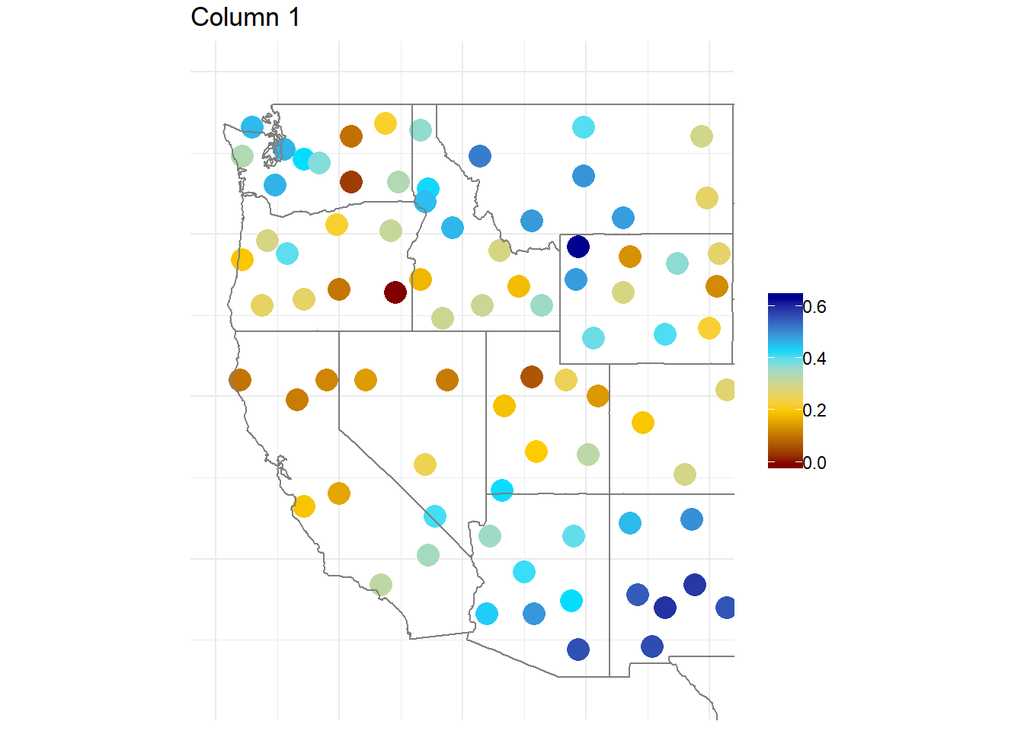

```r
## correlate the forecasted PCs with the historical PCs

p.pc.cor = diag(cor(ypred,p.pc))

## correlate the forecasted rainfall with the historical rainfall

p.cor = diag(cor(wintanom.pred,wintanom))

## Map correlation

comp = cbind(xlongs,xlats,p.cor)
comp = as.data.frame(comp) # data frame
colnames(comp) = c("xlongs","xlats","Correlation")
p_map(comp,1)
```

Using the data from *kaplan* SST, we will obtain the precipitation for the years 2017, 2018 (Nov 2016 - Mar 2017 and Nov 2017 - Mar 2018).

First, we obtain the PC of the SST for the given years (17-18):

```r
sst1718 = sstannavg[117:118,] %>% scale(.) # SST for the years 2017 - 2018

sst1718.pc = sst1718 %*% t.svd$u # Get PC
sst1718.pc = scale(sst1718.pc[,1:npc])  # Trim 5 first PC and scale

print(sst1718.pc)
```

```
##            [,1]       [,2]       [,3]       [,4]       [,5]
## [1,] -0.7071068  0.7071068 -0.7071068 -0.7071068  0.7071068
## [2,]  0.7071068 -0.7071068  0.7071068  0.7071068 -0.7071068
## attr(,"scaled:center")
## [1] 0 0 0 0 0
## attr(,"scaled:scale")
## [1] 10.1947094  1.3955343  5.9067984  2.1174829  0.4875919
```

The PC are used to predict the PC of the rainfall over the US, as follows:

```r
ypred.1718=sst1718.pc %*% AA %*% betahat

print(ypred.1718)
```

```
##            [,1]       [,2]        [,3]        [,4]       [,5]
## [1,] -0.5680796 -0.2975228  0.07251632 -0.08802064  0.5531865
## [2,]  0.5680796  0.2975228 -0.07251632  0.08802064 -0.5531865
```

With the PC of the rainfall, we can now map the predicted precipitations by back transforming the PC to the original space.

```r
p.pred1718.pc = matrix(0,nrow = dim(ypred.1718)[1],ncol = dim(p.pred.pc)[2])
p.pred1718.pc[,1:npc] = ypred.1718 # linear prediction of precip PC. using SST PC (whole space)

wintanom.pred1718= p.pred1718.pc %*% t(E) # scaled precip. prediction. Partial eof

wintanom.pred1718=t(t(wintanom.pred1718)*p.sd + p.mean) # rescale
```

We can now map the rainfall anomalies for the winters of 2017, 2018.

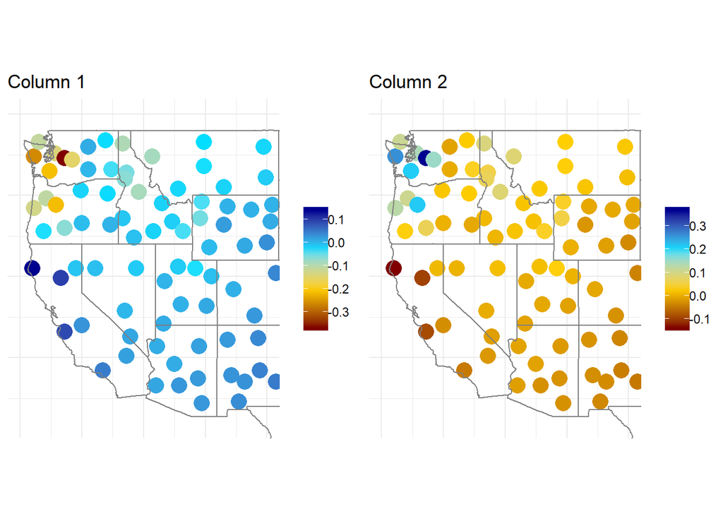

```r
comp = cbind(xlongs,xlats,t(wintanom.pred1718))
comp = as.data.frame(comp) # data frame
colnames(comp) = c("xlongs","xlats","Winter17","Winter18")

grid.arrange(p_map(comp,1),p_map(comp,2),nrow = 1)
```

The results indicate a low anormality with respect to average rainfall. This is coincident with the weak La Niña phenomena observed during the winters of 16-17 and 17-18.

#### Aux code to source libraries, functions and variables

```r
##
## Source Libraries
##

libr=c("magrittr","stats","maps","fields","graphics","ggplot2","gridExtra")
options(warn=-1)
suppressPackageStartupMessages(lapply(libr, require,character.only = TRUE))

##
## Source data
##

# load data

## Western US precipitation
wuplocs = matrix(scan("http://civil.colorado.edu/%7Ebalajir/CVEN6833/HWs/HW-2-2018/WesternUS-coords.txt"), ncol=5,byrow=T)

xlats = wuplocs[,3]
xlongs = -wuplocs[,4]

winterprecip = matrix(scan("http://civil.colorado.edu/%7Ebalajir/CVEN6833/HWs/HW-2-2018/western-US-winterprecip-1901-2014.txt"),ncol=82,byrow=T)
winterprecip = winterprecip[,2:82] # years = 1901:2013

aux =  colMeans(winterprecip)
wintanom = matrix(,ncol = 81, nrow = 113)

for(i in 1:113){
  wintanom[i,] = winterprecip[i,] - aux}

## Pacific SST

xgrid=seq(27.5,382.5,by=5) #Generate grid (-180,180) format
ygrid=seq(-87.5,87.5,by=5)

xygrid=expand.grid(x=xgrid,y=ygrid) %>% .[c("y","x")] # Lat - Long grid..

kaplan = # SST data row per NDJFM season format
  readBin("http://civil.colorado.edu/%7Ebalajir/CVEN6833/HWs/HW-2-2018/Kaplan-SST-NDJFM1900-NDJFM2018.r4",what="numeric", n=( 72 * 36 * 118), size=4,endian="swap") %>%
  array(data = ., dim=c( 72 * 36, 118 ) ) %>% t(.) # 2D

index1=kaplan[1,]<10 & kaplan[1,] != "NaN" # Remove out of bounds
sstdata=kaplan[,index1] # Drop missing data

#grid limits of tropical data
pacgrid = (xygrid$y >= -25 & xygrid$y <25) & (xygrid$x >= 105 & xygrid$x <= 290)

indexpac=index1 & pacgrid # locations on kaplan grid
xygrid1 = xygrid[indexpac,] # coordinates on kaplan grid

sstannavg = kaplan[,indexpac] # Pacific data

##
## Source functions
##
```